# prop_ecoreg_filled

2024-04-04

```r
library(here)
library(tidyverse)
library(magrittr)
library(janitor)
```

# Notes

# Summary

What is the actual number of ecoregions a parasite is found in compared to the maximum number of ecoregions a parasite could inhabit across different parasite groupings: (1) parasite type, (2) transmission mode, (3) host specificity, (4) high vs. low prevalence, (5) high vs. low intensity?

Overall method: Create two evenly sized groups divided by some feature of the parasite Measure actual number of ecoregions a parasite is found in from GMPD Measure maximum number of ecoregions a parasite could be found in assuming full host filling Compare ratio of actual:maximum for all parasites across feature

```r
host_para_mat <- readRDS(here("data", "processed_data", "para_mat.rds"))
ecoreg_host_mat <- readRDS(here("data", "processed_data", "ecoreg_mat.rds"))
ecoreg_para_mat <- readRDS(here("data", "processed_data", "ecoreg_para_mat.rds"))
null_para_df <- readRDS(here("data", "processed_data", "null_para_df.rds"))
gmpd_ecoreg_effort <- readRDS(here("data", "processed_data", "gmpd_ecoreg_effort.rds"))

gmpd <- read_csv(here("data", "GMPD", "GMPD_main.csv"))
gmpd_traits <- read_csv(here("data", "GMPD", "GMPD_parasite_traits.csv"))
ecoreg_names <- colnames(ecoreg_para_mat[2:ncol(ecoreg_para_mat)])
```

```r
gmpd %<>% filter(NativeRange=="Yes")
#gmpd %<>% filter(NativeRange!="No" | is.na(NativeRange))
```

# Add column for parasite type

```r
gmpd_type <- gmpd %>% dplyr::select(ParasiteCorrectedName, ParType) %>% distinct()

par_type_index <- tibble(ParType = c("Virus", "Bacteria", "Protozoa", "Prion", "Fungus", "Helminth", "Arthropod"),
                         ParMacroMicro = c("micro", "micro", "micro", "micro", "micro", "macro", "macro"))

gmpd_type %<>% left_join(., par_type_index)
gmpd_type %<>% rename(., para = ParasiteCorrectedName)
```

```r
para_names <- null_para_df %>% dplyr::select(para) %>% distinct()
gmpd_type %<>% filter(para %in% para_names$para)
```

There are some parasites called “not identified to genus” and these are different parasites so are creating issues when joining dataframes

```r
gmpd_type %<>% filter(!para == "not identified to genus")
null_para_df %<>% filter(!para == "not identified to genus")
```

```r
null_para_df %<>% left_join(., gmpd_type)
```

# Add column for transmission mode

```r
gmpd_mode <- gmpd_traits %>% mutate(mode =
                           ifelse(close == TRUE | nonclose == TRUE,
                                  "direct",
                                  "indirect")) %>%
  filter(!is.na(mode)) #remove parasites without mode data

gmpd_mode %<>% rename(para=ParasiteCorrectedName) %>% dplyr::select(para, mode)
```

```r
null_para_df %<>% left_join(., gmpd_mode)
```

# Add column for host specificity

```r
load(file=here("data", "GMPD", "get_nri.Rda"))
nri %<>% rownames_to_column(., var = "para")

nri %<>%
  filter(!is.na(mpd.obs.z)) %>%
  mutate(spec_bin = ifelse(
    mpd.obs.z<median(mpd.obs.z), #class determined above or below median
    "specialist",
    "generalist"
  ))

tabyl(nri$spec_bin)
```

```
##  nri$spec_bin   n   percent
##    generalist 394 0.5006353
##    specialist 393 0.4993647
```

```r
nri %<>% dplyr::select(para, spec_bin)

null_para_df %<>% left_join(., nri)
```

# Add column for prevalence

```r
gmpd_prev <- gmpd %>%
  dplyr::select(ParasiteCorrectedName, Prevalence) %>%
  filter(!is.na(Prevalence)) %>%
  group_by(ParasiteCorrectedName) %>%
  summarize(Prevalence=mean(Prevalence)) %>% #get average prevalence
  mutate(prev_bin = ifelse(
    Prevalence > median(Prevalence), #above or below median
    "high_prevalence",
    "low_prevalence"
  ))

tabyl(gmpd_prev$prev_bin)
```

```
##  gmpd_prev$prev_bin   n percent
##     high_prevalence 752     0.5
##      low_prevalence 752     0.5
```

```r
gmpd_prev %<>% rename(para = ParasiteCorrectedName) %>% dplyr::select(para, prev_bin)

null_para_df %<>% left_join(., gmpd_prev)
```

# Add column for intensity

```r
gmpd_int <- gmpd %>%
  dplyr::select(ParasiteCorrectedName, Intensity) %>%
  mutate(Intensity = as.numeric(Intensity)) %>% #some intensity measures included characters to indicate exponent or range. these are removed for now
  filter(!is.na(Intensity)) %>%
  filter(Intensity>0) %>% #some intensity measures were 0. these were removed
  group_by(ParasiteCorrectedName) %>%
  summarize(Intensity = mean(Intensity)) %>% #get average intensity
  mutate(int_bin = ifelse(
    Intensity > median(Intensity), #above or below median
    "high_intensity",
    "low_intensity"
  ))
tabyl(gmpd_int$int_bin)
```

```
##  gmpd_int$int_bin   n   percent
##    high_intensity 221 0.4900222
##     low_intensity 230 0.5099778
```

```r
gmpd_int %<>% rename(para = ParasiteCorrectedName) %>% dplyr::select(para, int_bin)

null_para_df %<>% left_join(., gmpd_int)
```

# actual ecoreg para mat with more attributes

```r
ecoreg_para_mat_vars <- ecoreg_para_mat %>% rename(para = ParasiteCorrectedName) %>%
  left_join(., gmpd_type) %>%
  left_join(., gmpd_mode) %>%
  left_join(., nri) %>%
  left_join(., gmpd_prev) %>%
  left_join(., gmpd_int)
group_vars <- c("ParType", "ParMacroMicro", "mode", "spec_bin", "prev_bin", "int_bin")
```

# proportion filled function

```r
get_para_ecoreg <- function(VarName){

  vars <- null_para_df %>% dplyr::select(VarName) %>% distinct() %>% filter(!is.na(.))

  actual_ecoreg_first <- ecoreg_para_mat_vars %>%
    filter(!!sym(VarName) == vars[[1,1]]) %>%
    dplyr::select(-group_vars) %>%
    pivot_longer(all_of(ecoreg_names)) %>%
    filter(value == TRUE) %>%
    group_by(para) %>%
    distinct() %>%
    summarize(n_ecoreg = n())

  actual_ecoreg_second <- ecoreg_para_mat_vars %>%
    filter(!!sym(VarName) == vars[[2,1]]) %>%
    dplyr::select(-group_vars) %>%
    pivot_longer(all_of(ecoreg_names)) %>%
    filter(value == TRUE) %>%
    group_by(para) %>%
    distinct() %>%
    summarize(n_ecoreg = n())

  max_ecoreg_first <- null_para_df %>%
    filter(!!sym(VarName) == vars[[1,1]]) %>%
    dplyr::select(para, name) %>%
    group_by(para) %>% distinct() %>%
    summarize(n_ecoreg = n())

  max_ecoreg_second <- null_para_df %>%
    filter(!!sym(VarName) == vars[[2,1]]) %>%
    dplyr::select(para, name) %>%
    group_by(para) %>% distinct() %>%
    summarize(n_ecoreg = n())

  max_ecoreg_first %<>%
    left_join(., actual_ecoreg_first, by=c("para")) %>%
    mutate(
      n_ecoreg.y = replace_na(n_ecoreg.y, 0),
      binary = vars[[1,1]])

  max_ecoreg_second %<>%
    left_join(., actual_ecoreg_second, by=c("para")) %>%
    mutate(
      n_ecoreg.y = replace_na(n_ecoreg.y, 0),
      binary = vars[[2,1]])

  para_binary_ecoreg <- rbind(max_ecoreg_first, max_ecoreg_second)

  para_binary_ecoreg %<>% mutate(ratio = n_ecoreg.y/n_ecoreg.x)

  return(para_binary_ecoreg)
}
```

```r
type_ratios <- get_para_ecoreg("ParMacroMicro")
mode_ratios <- get_para_ecoreg("mode")
spec_ratios <- get_para_ecoreg("spec_bin")
prev_ratios <- get_para_ecoreg("prev_bin")
int_ratios <- get_para_ecoreg("int_bin")
```

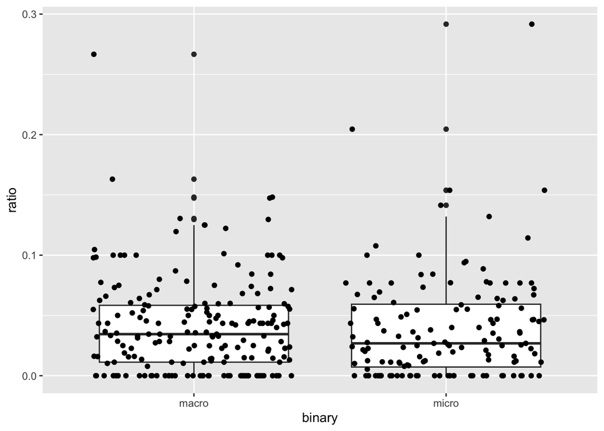

```r
type_ratios %>% filter(ratio<1) %>% ggplot(., aes(x=binary, y=ratio)) + geom_boxplot() + geom_jitter()
```

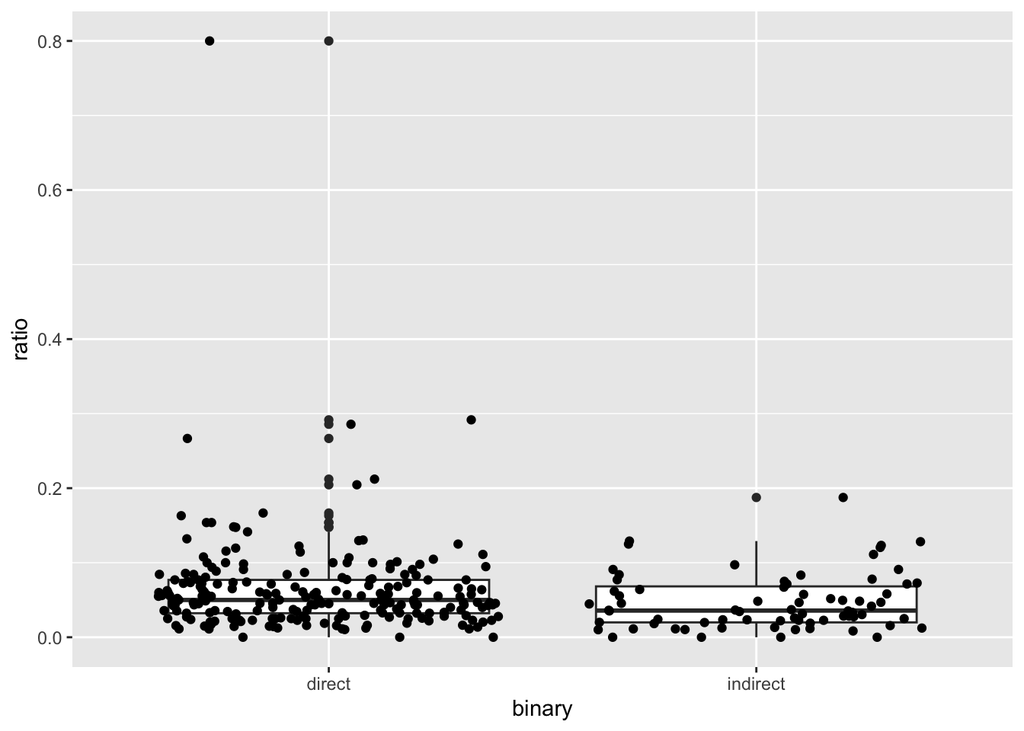

```r
mode_ratios %>% filter(ratio<1) %>% ggplot(., aes(x=binary, y=ratio)) + geom_boxplot() + geom_jitter()
```

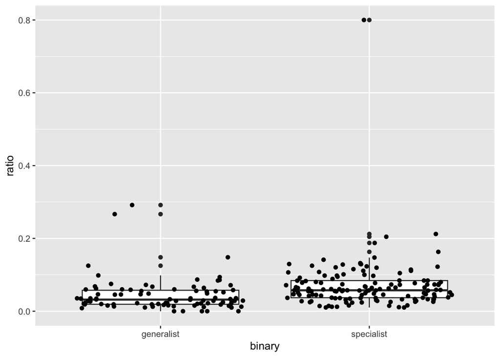

```r
spec_ratios %>% filter(ratio<1) %>% ggplot(., aes(x=binary, y=ratio)) + geom_boxplot() + geom_jitter()
```

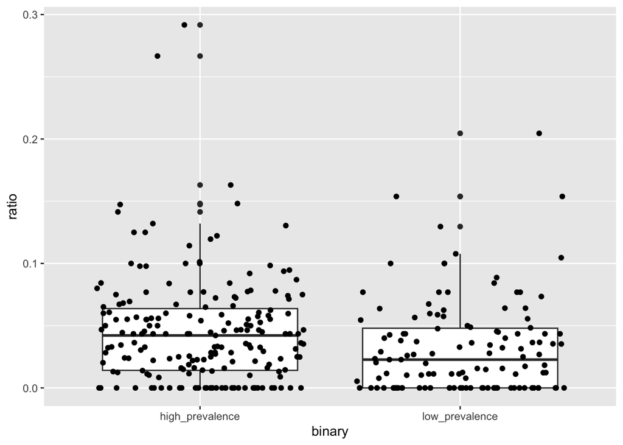

```r
prev_ratios %>% filter(ratio<1) %>% ggplot(., aes(x=binary, y=ratio)) + geom_boxplot() + geom_jitter()
```

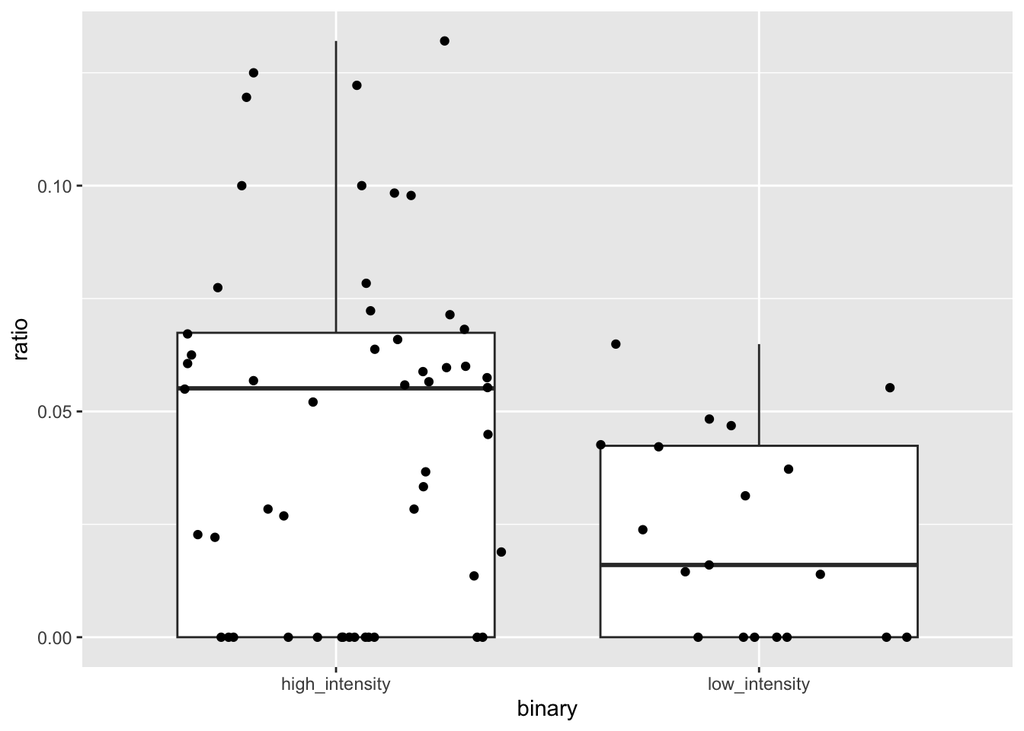

```r
int_ratios %>% filter(ratio<1) %>% ggplot(., aes(x=binary, y=ratio)) + geom_boxplot() + geom_jitter()
```

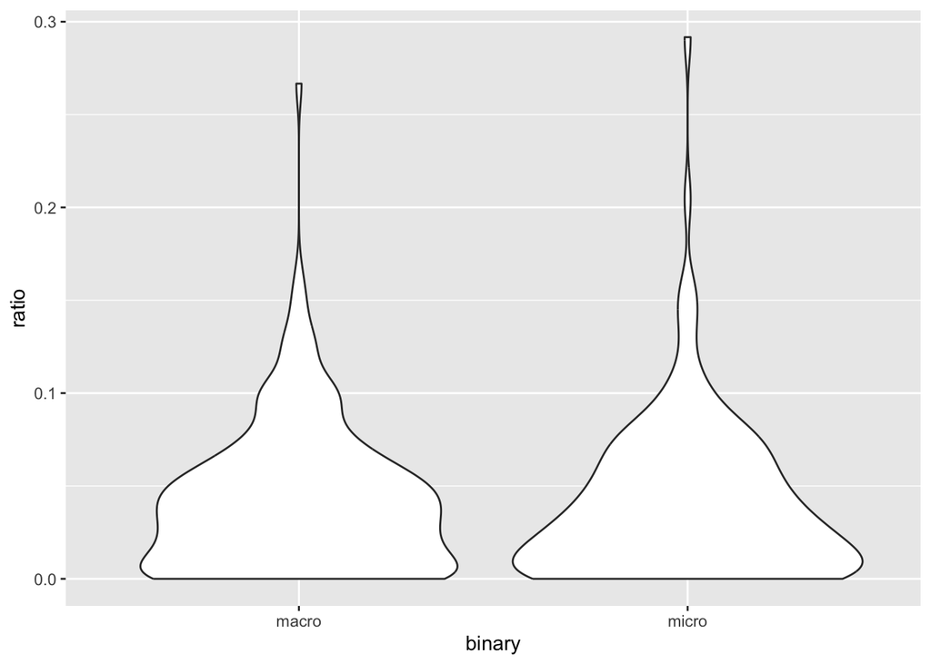

```r
type_ratios %>% filter(ratio<1) %>% ggplot(., aes(x=binary, y=ratio)) + geom_violin()
```

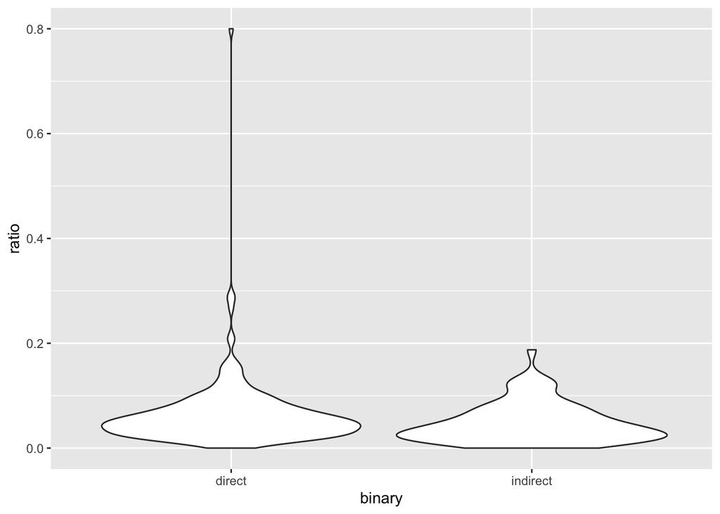

```r
mode_ratios %>% filter(ratio<1) %>% ggplot(., aes(x=binary, y=ratio)) + geom_violin()
```

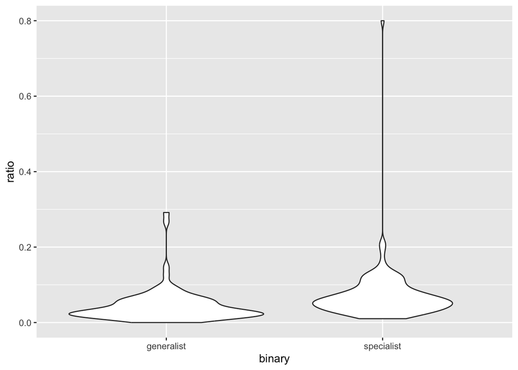

```r
spec_ratios %>% filter(ratio<1) %>% ggplot(., aes(x=binary, y=ratio)) + geom_violin()
```

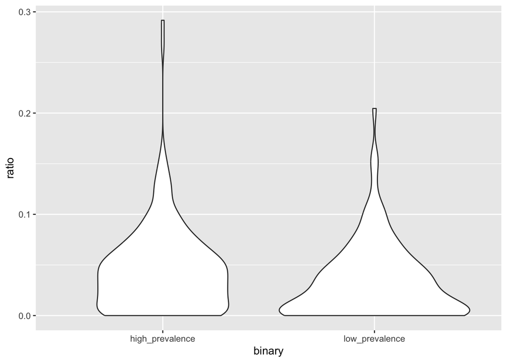

```r
prev_ratios %>% filter(ratio<1) %>% ggplot(., aes(x=binary, y=ratio)) + geom_violin()
```

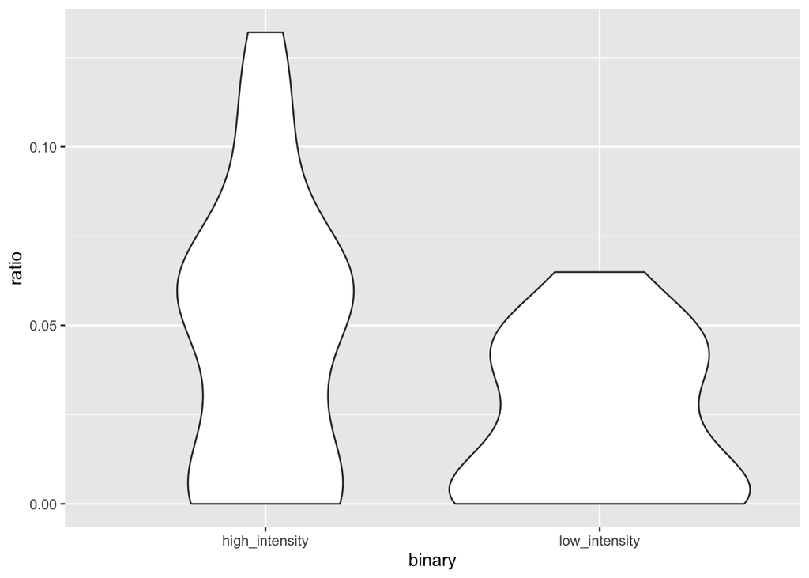

```r
int_ratios %>% filter(ratio<1) %>% ggplot(., aes(x=binary, y=ratio)) + geom_violin()
```

two-tailed, non-parametric

```r
wilcox.test(ratio ~ binary, data = type_ratios)
```

```
##
##  Wilcoxon rank sum test with continuity correction
##
## data:  ratio by binary
## W = 14100, p-value = 0.393
## alternative hypothesis: true location shift is not equal to 0
```

```r
wilcox.test(ratio ~ binary, data = mode_ratios)
```

```
##
##  Wilcoxon rank sum test with continuity correction
##
## data:  ratio by binary
## W = 9339.5, p-value = 0.005708
## alternative hypothesis: true location shift is not equal to 0
```

```r
wilcox.test(ratio ~ binary, data = spec_ratios)
```

```
##
##  Wilcoxon rank sum test with continuity correction
##
## data:  ratio by binary
## W = 3383.5, p-value = 8.999e-08
## alternative hypothesis: true location shift is not equal to 0
```

```r
wilcox.test(ratio ~ binary, data = prev_ratios)
```

```
##
##  Wilcoxon rank sum test with continuity correction
##
## data:  ratio by binary
## W = 14228, p-value = 0.001462
## alternative hypothesis: true location shift is not equal to 0
```

```r
wilcox.test(ratio ~ binary, data = int_ratios)
```

```
##
##  Wilcoxon rank sum test with continuity correction
##
## data:  ratio by binary
## W = 675, p-value = 0.01754
## alternative hypothesis: true location shift is not equal to 0
```

Do this once more but for all of the parasites and all of the ecoregions without subsetting to the different binary groups.

Then see if there are any patterns when we break those groups up by traits.

Max ecoreg filled per parasite

```r
max_ecoreg <- null_para_df %>%
  group_by(para) %>%
  dplyr::select(para, name) %>%
  distinct() %>%
  summarize(max_ecoreg = n())
```

```r
actual_ecoreg <- ecoreg_para_mat_vars %>%
    dplyr::select(-group_vars) %>%
    pivot_longer(all_of(ecoreg_names)) %>%
    filter(value == TRUE) %>%
    group_by(para) %>%
    distinct() %>%
    summarize(n_ecoreg = n())
```

```r
ecoreg_binary <- null_para_df %>%
  group_by(para) %>%
  dplyr::select(para, ParMacroMicro:int_bin) %>%
  distinct()
```

```r
ecoreg_filled <- left_join(max_ecoreg, actual_ecoreg, by = "para")
ecoreg_filled %<>% left_join(., ecoreg_binary, by = "para")
ecoreg_filled %<>% mutate(ratio = n_ecoreg/max_ecoreg)
```

```r
ecoreg_filled %<>% filter(!is.na(ratio))
```

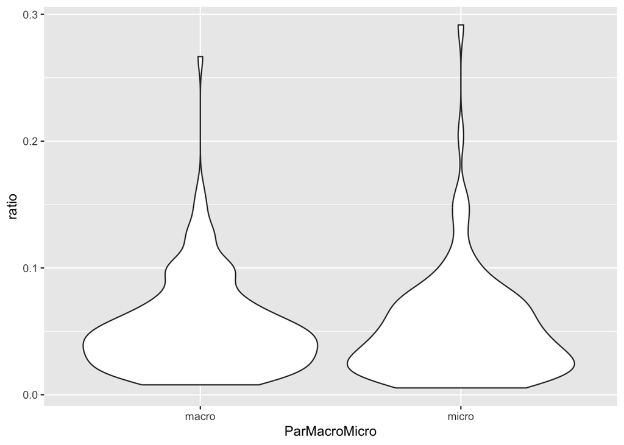

```r
ecoreg_filled %>% filter(!is.na(ParMacroMicro)) %>%
  ggplot(., aes(x=ParMacroMicro, y=ratio)) + geom_violin()
```

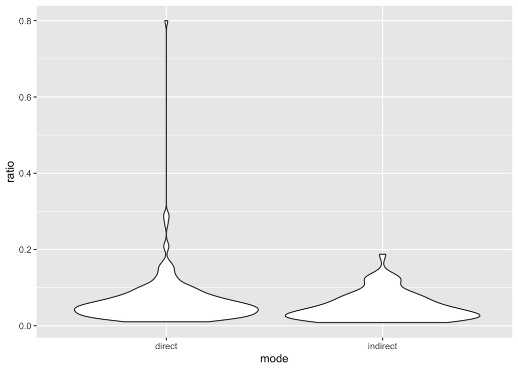

```r
ecoreg_filled %>% filter(!is.na(mode)) %>%
  ggplot(., aes(x=mode, y=ratio)) + geom_violin()
```

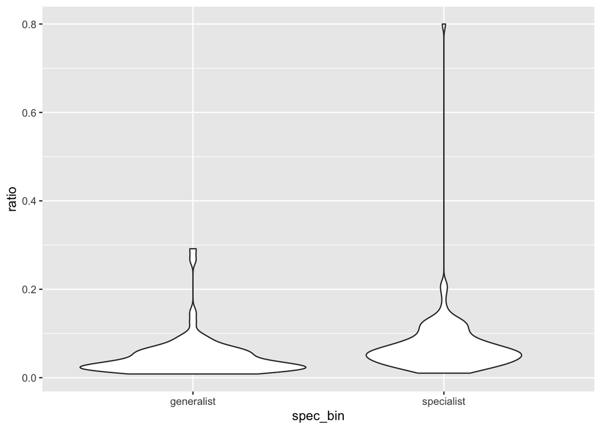

```r
ecoreg_filled %>% filter(!is.na(spec_bin)) %>%
  ggplot(., aes(x=spec_bin, y=ratio)) + geom_violin()
```

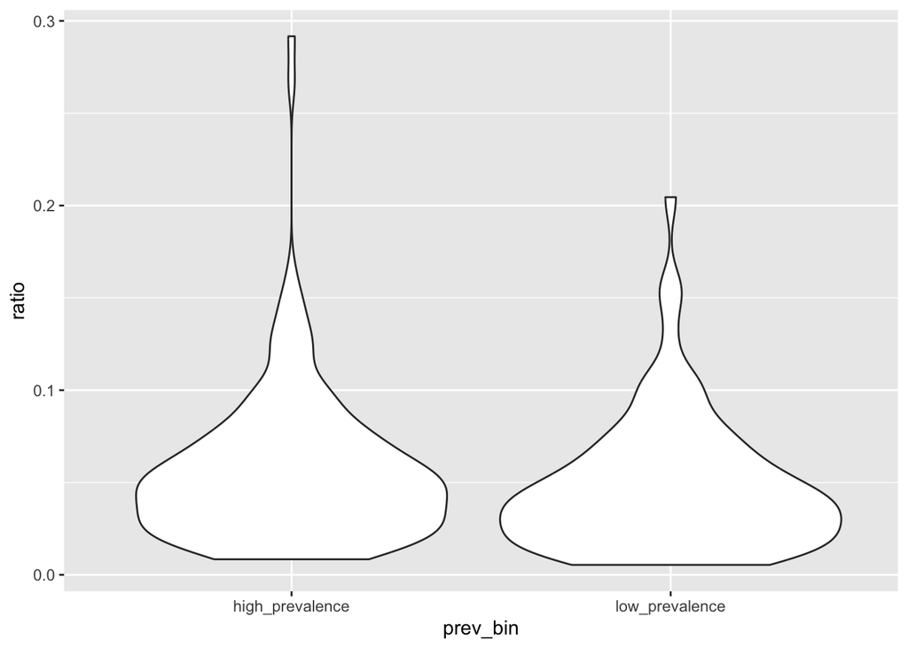

```r
ecoreg_filled %>% filter(!is.na(prev_bin)) %>%
  ggplot(., aes(x=prev_bin, y=ratio)) + geom_violin()
```

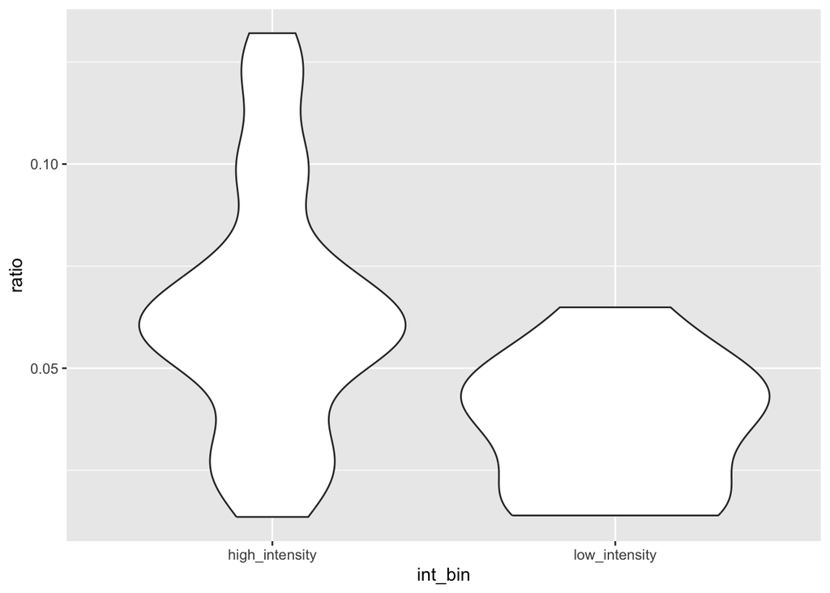

```r
ecoreg_filled %>% filter(!is.na(int_bin)) %>%
  ggplot(., aes(x=int_bin, y=ratio)) + geom_violin()
```

```r
wilcox.test(ratio ~ ParMacroMicro, data = ecoreg_filled)
```

```
##
##  Wilcoxon rank sum test with continuity correction
##
## data:  ratio by ParMacroMicro
## W = 8337.5, p-value = 0.3931
## alternative hypothesis: true location shift is not equal to 0
```

```r
wilcox.test(ratio ~ mode, data = ecoreg_filled)
```

```
##
##  Wilcoxon rank sum test with continuity correction
##
## data:  ratio by mode
## W = 8493.5, p-value = 0.01886
## alternative hypothesis: true location shift is not equal to 0
```

```r
wilcox.test(ratio ~ spec_bin, data = ecoreg_filled)
```

```
##
##  Wilcoxon rank sum test with continuity correction
##
## data:  ratio by spec_bin
## W = 3383.5, p-value = 1.511e-06
## alternative hypothesis: true location shift is not equal to 0
```

```r
wilcox.test(ratio ~ prev_bin, data = ecoreg_filled)
```

```
##
##  Wilcoxon rank sum test with continuity correction
##
## data:  ratio by prev_bin
## W = 7500.5, p-value = 0.04201
## alternative hypothesis: true location shift is not equal to 0
```

```r
wilcox.test(ratio ~ int_bin, data = ecoreg_filled)
```

```
##
##  Wilcoxon rank sum test with continuity correction
##
## data:  ratio by int_bin
## W = 360, p-value = 0.002816
## alternative hypothesis: true location shift is not equal to 0
```